# Conducción autónoma en calles de Santa Fe mediante neuroevolución

M. Bertona, A. Greminger y A. Nanzer

Inteligencia Computacional · Facultad de Ingeniería y Ciencias Hídricas · Universidad Nacional del Litoral

# La idea

## Conducción autónoma

¿Se le puede enseñar a un auto a manejar sin decirle cómo?

Queremos que un auto vaya solo de **A** a **B** por calles reales de Santa Fe, sin salirse de la calle y por su carril.

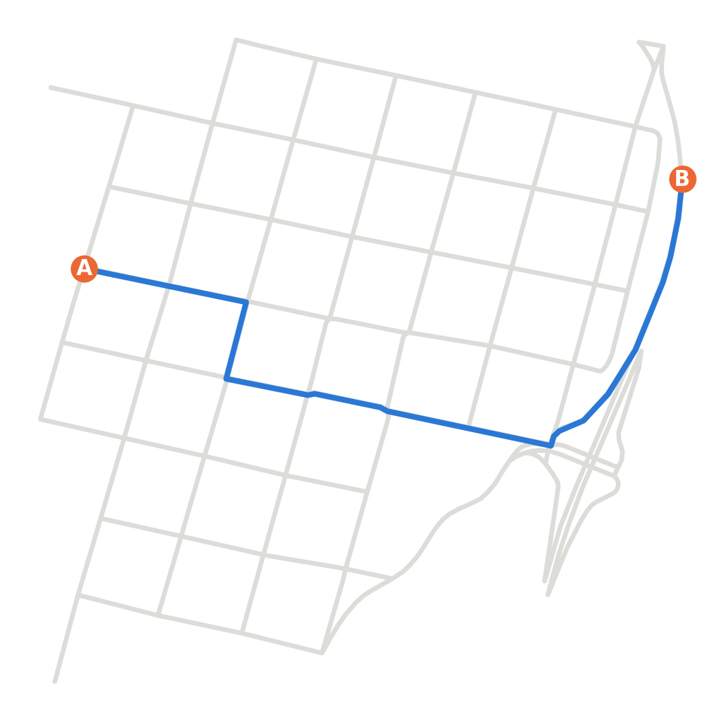

# Antecedentes

## ¿Cómo se mueve un auto, con las cuentas más simples?

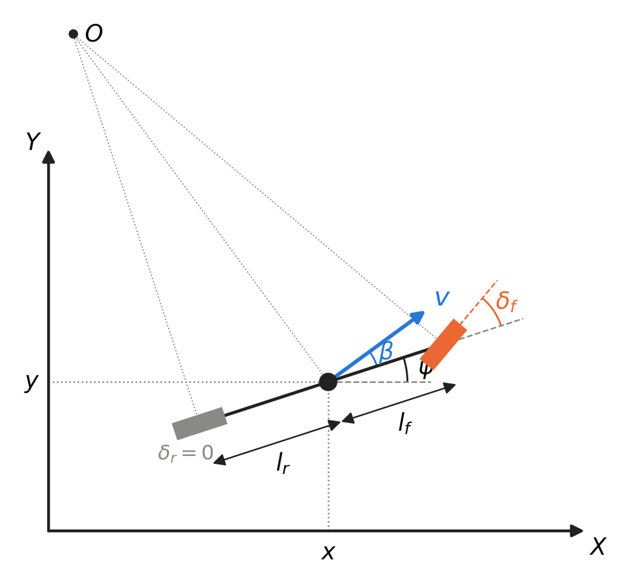

Kong et al. (2015), fig. 1

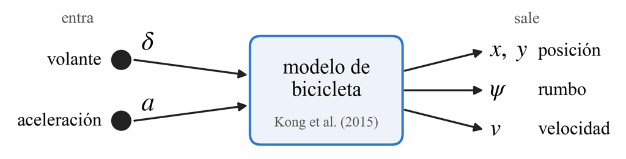

- **Al modelo entran** las dos decisiones de quien maneja: volante y aceleración
- **Del modelo sale** dónde queda el auto: posición, rumbo y velocidad. Desde ahí, quien maneja vuelve a mirar y decide de nuevo

Modelo cinemático de bicicleta (Kong et al., 2015): $\dot x = v\cos(\psi+\beta)$, $\dot y = v\sin(\psi+\beta)$, $\dot\psi = \frac{v}{\ell_r}\sin\beta$, $\dot v = a$, con $\beta = \arctan\!\left(\frac{\ell_r}{\ell_f+\ell_r}\tan\delta\right)$.

## ¿Qué se sabía antes de empezar?

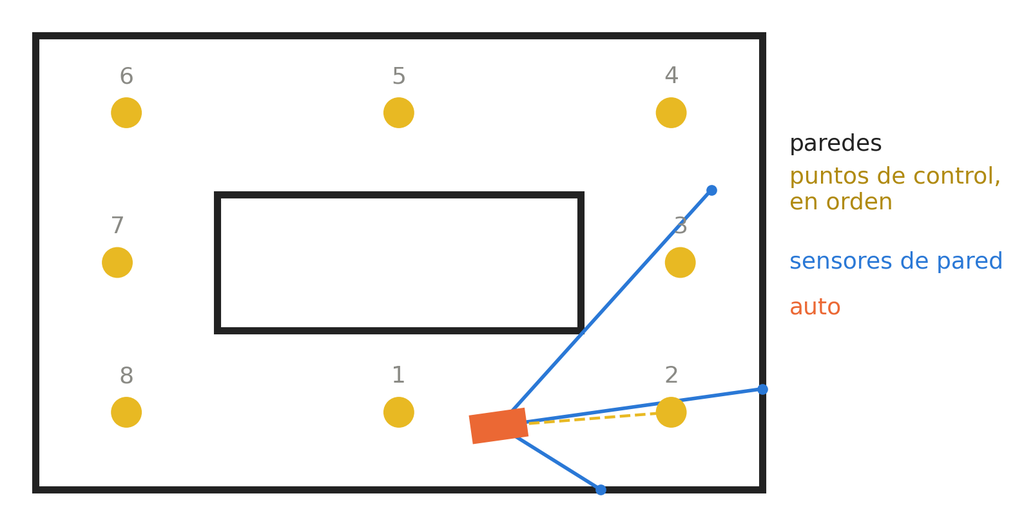

Togelius y Lucas (2005), p. 1911

**¿Se puede enseñar a manejar con un algoritmo evolutivo?**  
Sí, sin ejemplos: se elige la red que más avanza. Togelius y Lucas, 2005, 2006

**¿Se puede entrenar una red con un genético?**  
Sí, con sus pesos en fila, como números reales. Montana y Davis, 1989

**¿Cómo se cruzan y se mutan las redes?**  
Con cuidado: el orden de las neuronas importa. Yao, 1999

**¿Qué fitness se le pone a un viaje?**  
Cuánto avanzó, no solo si llegó. Nelson et al., 2009

**¿Cómo se aprende algo difícil?**  
De a poco, de lo fácil a lo difícil. Gomez y Miikkulainen, 1996

**¿Y el resto?**  
Intentamos leerlo todo. (No pudimos.)

**Pero todo esto en pistas de juguete: sin calles, sin carriles y sin esquinas.**

# Lo que proponemos

## Nuestras seis propuestas

1. **Calles reales de Santa Fe:** rutas de A a B, por el carril derecho
2. **Una red que mira el carril** 3 y 6 m adelante, además de los bordes y el próximo punto
3. **Un fitness que premia avanzar por su carril**
4. **Comparar** cuatro formas de cruzar y dos de mutar
5. **Entrenar por etapas:** de una manzana a mapas cada vez más grandes
6. **Un límite de agarre,** para que maneje como puede un auto real

## 1 · Calles reales, por su carril

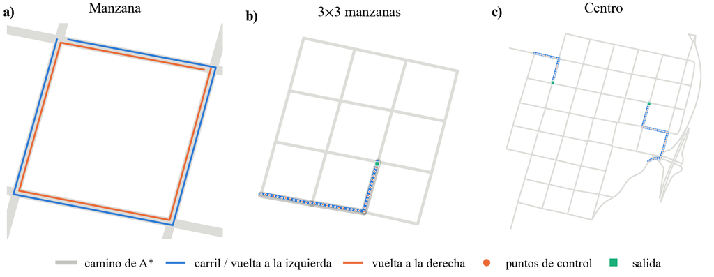

- **Calles reales de Santa Fe:** el camino más corto de A a B
- **Puntos de control** sobre el carril derecho
- **Un punto en cada giro,** para que no corte la esquina
- **Puntos que se pueden saltear,** para no quedar trabado

Calles de OpenStreetMap, descargadas con OSMnx (Boeing, 2025). Camino más corto con A* (Hart et al., 1968).

## 2 · La red: qué ve y qué decide

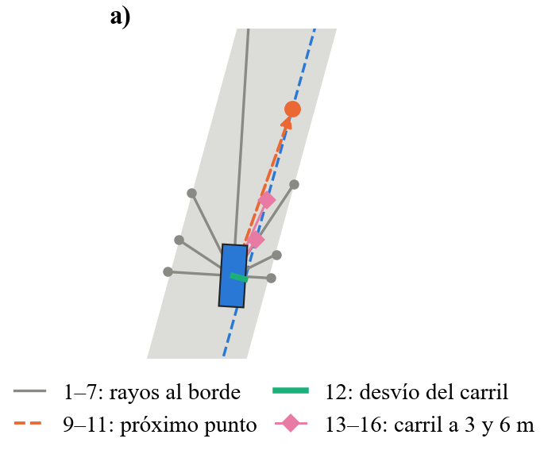

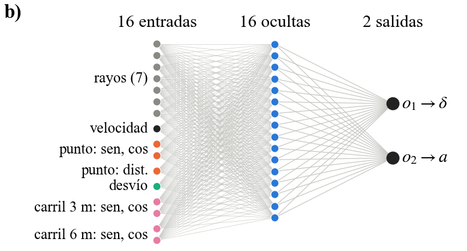

- **16 entradas**, medidas desde el auto: 7 rayos al borde, velocidad, próximo punto, desvío del carril y el carril 3 y 6 m adelante
- **2 salidas**, las que entran a la caja del modelo del auto: volante = 35° · o₁; acelerador 2 m/s² · o₂ si o₂ > 0, freno 4 m/s² · o₂ si no

## 3 · El fitness: avanzar por su carril

$$F_r = \frac{k_r + p_r}{K_r}\,\bigl(1 - c\,f_r\bigr)$$

- **Avance:** los $k_r$ puntos de control pasados, más lo que avanzó hacia el siguiente ($p_r$), sobre el total $K_r$. Mide cuánto avanzó y no solo si llegó, porque al principio ninguna red llega y todas sacarían cero
- **Carril (lo nuestro):** se descuenta $c = 0{,}8$ por la fracción $f_r$ del tiempo que anduvo fuera de su carril

El fitness de la red es el promedio de sus rutas. El viaje termina si llega, si se sale de la calle o si se acaba el tiempo ($t_{\max,r}$ = largo de la ruta / 4 m/s + 10 s).

## 4 · Las opciones que comparamos

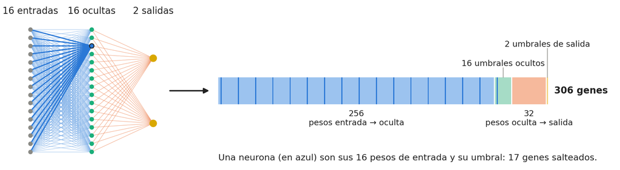

| Operador | Qué hace |
| --- | --- |
| Cruce por neurona | Copia cada neurona entera (los 17 genes azules) de uno de los padres |
| Cruce por pesos | Copia cada peso del padre o de la madre, al azar |
| Cruce BLX-α | Sortea cada peso entre los de los padres, con el intervalo agrandado α = 0,5 |
| Sin cruce | El hijo es copia de un padre; solo cambia por la mutación |
| Mutación gaussiana | A cada peso, con probabilidad 0,05, le suma ruido normal de desvío σ |
| Mutación por neurona | Elige 2 neuronas y les suma ruido normal a sus 17 genes |

¿Por qué un genético? Para retropropagar hace falta el volante correcto en cada paso; nosotros solo tenemos un fitness al final del viaje.

## 5 · El algoritmo, etapa por etapa

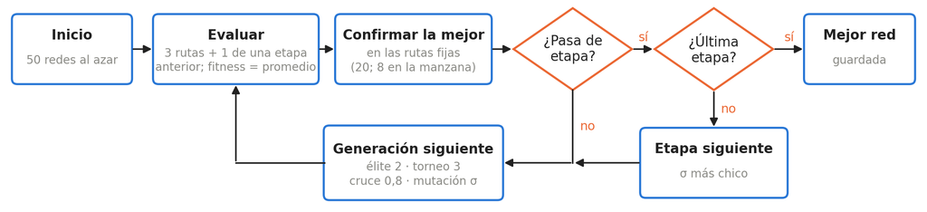

- **Para evolucionar, rutas al azar:** cada generación, las 50 redes manejan 3 rutas al azar de la etapa y 1 de una etapa anterior, para no olvidar. Con ese fitness se eligen los padres
- **Para elegir, rutas fijas:** con 3 rutas, una red puede tener suerte. Por eso la de mejor fitness se prueba en las rutas fijas de la etapa, siempre las mismas (20; 8 en la manzana)
- **Se guarda** si llega en más rutas fijas que la mejor hasta ahora. Con esas mismas rutas se decide cuándo pasar de etapa

## 5 · Las etapas

De lo fácil a lo difícil: la población arranca en una manzana y sube a mapas más grandes, sin reiniciarse.

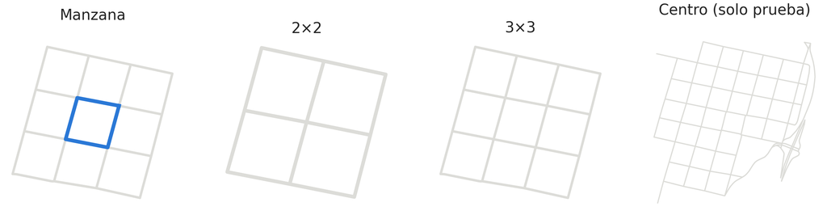

| Etapa | σ de la mutación | Pasa si la mejor llega en (desde la generación 10) | Generaciones |
| --- | --- | --- | --- |
| Manzana (vueltas a la del medio) | 0,3 | todas las rutas fijas | de 10 a 100 |
| 2×2 | 0,2 | el 90 % | de 10 a 50 |
| 3×3 | 0,15 | (última etapa) | 50 |

## 5 · Así se ve entrenar

[video not shown]

Las 50 redes de una generación manejan a la vez la misma ruta. En azul, la de mejor fitness.

## 6 · El límite de agarre

- **El problema:** el modelo del auto deja doblar a fondo a cualquier velocidad. La primera versión llegaba rápido a las esquinas y se salía
- **El límite:** para doblar hace falta una aceleración centrípeta, $v^2/R$: la que se siente de costado en una curva. La limitamos a 6 m/s², algo más de media g, lo que aguantan las gomas. A más velocidad, menos volante
- **No frena:** frenar antes de la esquina lo tiene que aprender la red

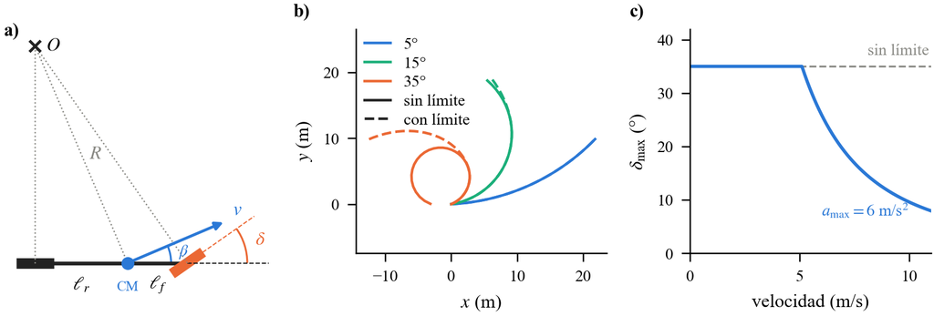

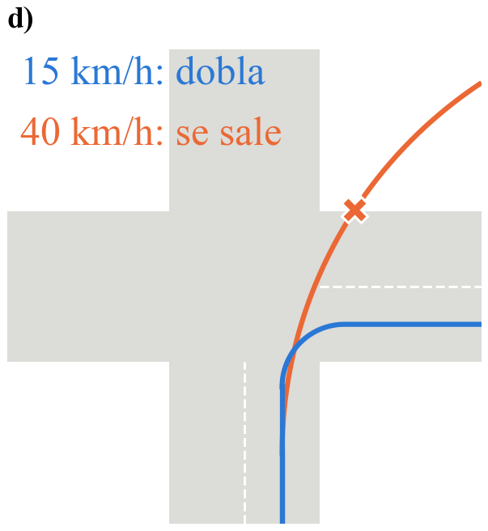

Trayectorias sin y con límite (b), volante máximo según la velocidad (c) y la misma esquina a dos velocidades, con el límite (d): hasta 5,1 m/s (18 km/h) dobla a fondo; a 40 km/h no entra en la esquina.

# Resultados

## Tres preguntas

1. **¿Qué hace la red si la física no la limita?** Sin límite de agarre contra con límite de 6 m/s².
2. **¿Importa el operador?** Cinco corridas: los cuatro cruces con mutación gaussiana, y cruce y mutación por neurona.
3. **¿Maneja en calles donde nunca entrenó?** En el centro y en seis barrios que no se usaron para entrenar.

Seis corridas: las cinco de los operadores, con límite de agarre, y una sin límite. Una semilla. Se prueba con 20 rutas fijas, sin ruido en los sensores.

## P1: sin el límite, la red hace trampa

[video not shown]

| En el centro, 20 rutas | Llega | Tiempo medio | Velocidad cerca / lejos de un giro | Aceleración lateral máxima |
| --- | --- | --- | --- | --- |
| Sin límite | 20 / 20 | 56 s | 40 / 37 km/h | **27,6 m/s²** (casi 3 g) |
| Con límite | 15 / 20 | 111 s | 19 / 18 km/h | **6,3 m/s²** |

Sin límite llega siempre y en la mitad del tiempo, porque aprovecha una física imposible. Misma ruta del centro, a 4× del tiempo real.

## P2 y P3: operadores y calles nuevas

| Cruce | Mutación | Llega en el centro | Tiempo medio |
| --- | --- | --- | --- |
| por neurona | gaussiana | 15 / 20 | 111 s |
| por pesos | gaussiana | 20 / 20 | 142 s |
| BLX-α | gaussiana | 19 / 20 | 128 s |
| sin cruce | gaussiana | 19 / 20 | 135 s |
| por neurona | por neurona | 17 / 20 | 129 s |

- **P3:** todas aprendieron en la manzana, el 2×2 y el 3×3, y llegan en 15 a 20 de 20 rutas del centro, con diagonales, una avenida curva y cruces que no estaban en esos mapas
- **P2:** con una sola semilla, esas diferencias pueden ser suerte. Todos los operadores aprenden; para ordenarlos hacen falta más semillas

## P2: las cinco, en la misma ruta

[video not shown]

Una ruta del centro, de 826 m y 5 giros. Es un ejemplo: los números de la comparación están en la tabla.

## P3: cada red en un barrio que nunca vio

[video not shown]

Abajo de cada red, cómo le fue en las 20 rutas fijas de su barrio. Los barrios son distintos: para comparar operadores está la tabla del centro.

# Cierre

## Conclusiones

**Lo que propusimos:** entrenar por etapas, en calles reales, una red que maneja por su carril, con un límite de agarre que la obliga a manejar como un auto real.

1. Sin límite de agarre, la red aprovecha la física. Con el límite maneja dentro de lo posible, pero lento.
2. Todos los operadores aprenden; con una semilla no alcanza para ordenarlos.
3. Lo aprendido en recortes chicos sirve en el centro y en barrios que nunca vio.

Lo que sigue: más semillas, premio por tiempo para que aprenda a frenar antes de las esquinas, tráfico y semáforos.

## Respaldo: los parámetros

|  | Parámetro | Valor |
| --- | --- | --- |
| Red | capas / desvío de pesos iniciales / ruido de sensores | 16 → 16 → 2 / 0,1 / 0,02 |
| Algoritmo genético | población / torneo / élite | 50 / 3 / 2 |
|  | cruce / probabilidad | por neurona / 0,8 |
|  | mutación / probabilidad por gen | gaussiana / 0,05 |
|  | rutas por generación / fijas | 3 / 20 |
| Fitness | descuento por carril | 0,8 |
| Auto | límite de agarre | 6 m/s² |